# Errors spec-seq

# ZFP57

```
   Genotype          Score_nomet        Score_met          Difference
 Length:64          Min.   :-3.5496   Min.   :-1.36407   Min.   :1.448
 Class :character   1st Qu.:-2.2457   1st Qu.:-0.08484   1st Qu.:2.020
 Mode  :character   Median :-2.0129   Median : 0.23072   Median :2.115
                    Mean   :-1.9273   Mean   : 0.21685   Mean   :2.144
                    3rd Qu.:-1.3935   3rd Qu.: 0.64422   3rd Qu.:2.276
                    Max.   :-0.7831   Max.   : 1.18737   Max.   :2.636
 Contains_CpG
 True:64
```

Plot of all sequences

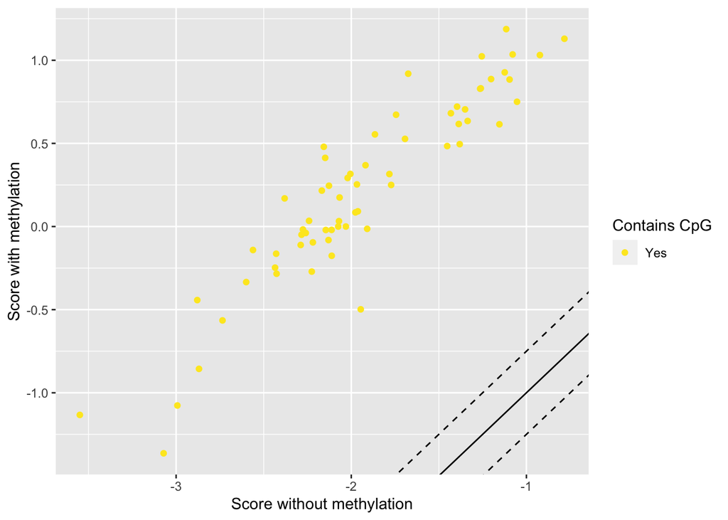

```r
ggplot(ZFP57, aes(x=Score_nomet, y=Score_met, color=Contains_CpG))+geom_point()+geom_abline(slope=1, intercept = 0) + geom_abline(slope=1, intercept = 0.25, linetype="dashed") + geom_abline(slope=1, intercept = -0.25, linetype="dashed")+scale_color_viridis(discrete=TRUE, direction=-1, name="Contains CpG", labels=("Yes"))+xlab("Score without methylation")+ylab("Score with methylation")
```

```r
ggsave(paste(path, "ZFP57/Plots/ZFP57_scatter.png", sep="/"))
```

Violin plot of distribution of the scores between methylated and non methylated sequences.

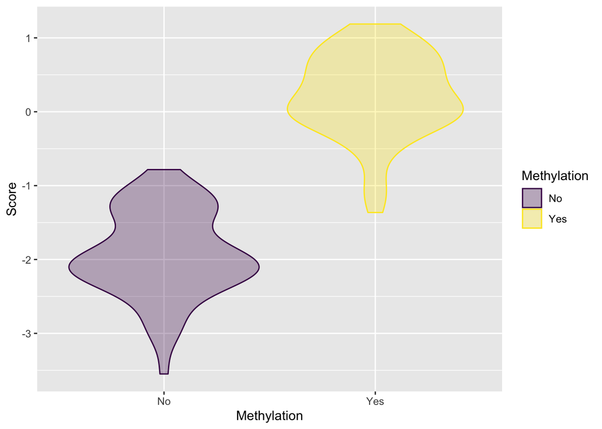

```r
ZFP57_mod <- melt(ZFP57, measure.vars = c('Score_nomet', 'Score_met'), variable.name="Methylation")
levels(ZFP57_mod$Methylation) <- c("No", "Yes")
ggplot(data=ZFP57_mod)+geom_violin(aes(Methylation, value, color=Methylation, fill=Methylation))+scale_color_viridis(discrete=TRUE)+scale_fill_viridis(discrete = TRUE, alpha=0.3)+ylab("Score")
```

```r
ggsave(paste(path, "ZFP57/Plots/ZFP57_violin.png", sep="/"))
```

Are the non-methylated scores normally distributed ?

```r
shapiro.test(ZFP57$Score_nomet)
```

```
    Shapiro-Wilk normality test

data:  ZFP57$Score_nomet
W = 0.97159, p-value = 0.1464
```

Are the methylated scores normally distributed ?

```r
shapiro.test(ZFP57$Score_met)
```

```
    Shapiro-Wilk normality test

data:  ZFP57$Score_met
W = 0.96639, p-value = 0.07838
```

Is there a change between non-methylated and methylated sequences

```r
wilcox.test(ZFP57$Score_nomet, ZFP57$Score_met, paired=TRUE)
```

```
    Wilcoxon signed rank test with continuity correction

data:  ZFP57$Score_nomet and ZFP57$Score_met
V = 0, p-value = 3.61e-12
alternative hypothesis: true location shift is not equal to 0
```

Rejection of null hypothesis of no difference between not methylated and methylated sequences

Are the scores of methylated sequences greater than the one of non-methylated sequences ?

```r
wilcox.test(ZFP57$Score_nomet, ZFP57$Score_met, paired=TRUE, alternative="less")
```

```
    Wilcoxon signed rank test with continuity correction

data:  ZFP57$Score_nomet and ZFP57$Score_met
V = 0, p-value = 1.805e-12
alternative hypothesis: true location shift is less than 0
```

Are the scores of methylated sequences smaller than the one of non-methylated sequences ?

```r
wilcox.test(ZFP57$Score_nomet, ZFP57$Score_met, paired=TRUE, alternative="greater")
```

```
    Wilcoxon signed rank test with continuity correction

data:  ZFP57$Score_nomet and ZFP57$Score_met
V = 0, p-value = 1
alternative hypothesis: true location shift is greater than 0
```